# Preprocessing and First Level Model for Task fMRI with ACPC Alignment

John Muschelli

2021-03-03

# Overview of `spm12r` functions

Requires MATLAB (installs SPM to R library)

- `spm12_slice_timing` - slices are not taken instantaneously
- `spm12_realign` - people move
- `spm12_coregister` - structural imaging is higher resolution
- `spm12_segment` - where’s the gray matter?
- `spm12_normalize` - brains look better in MNI
- `spm12_smooth` - turn that noise down

# Data used

```r
library(httr)
install_dir = tempdir()
url = paste0("https://ndownloader.figshare.com/articles/",
             "5442298/versions/1")
zipfile = tempfile(fileext = ".zip")
res = GET(
  url,
  write_disk(path = zipfile),
  if (interactive()) progress())
run_dir = tempfile()
if (!dir.exists(run_dir)) {
  dir.create(run_dir)
}
out_files = utils::unzip(zipfile, exdir = run_dir)
names(out_files) = neurobase::nii.stub(
  out_files, bn = TRUE)
```

```r
library(neurobase)
##################################
# Added quick reading of nifti header
##################################
oro_pkg = packageVersion("oro.nifti")
neuro_pkg = packageVersion("neurobase")
if (oro_pkg < 0.8 || neuro_pkg < 1.22) {
  get_nifti = neurobase::check_nifti
} else {
  get_nifti = neurobase::check_nifti_header
}

fmri_filename = out_files["fmri"]
t1_fname = out_files["anat"]
tr = 1.8 # seconds
hdr = get_nifti(fmri_filename) # getting nifti header

nslices = oro.nifti::nsli(hdr)
n_time_points = oro.nifti::ntim(hdr)
time_points = seq(n_time_points)
ta = 0
slice_order = c(
  1740, 1680, 1620, 1560, 1500, 1440, 1380,
  1320, 1260, 1200, 1140, 1080, 1020, 960,
  900, 840, 780, 720, 660, 600, 540, 480,
  420, 360, 300, 240, 180, 120, 60, 0,
  1740, 1680, 1620, 1560, 1500, 1440, 1380,
  1320, 1260, 1200, 1140, 1080, 1020, 960,
  900, 840, 780, 720, 660, 600, 540, 480, 420,
  360, 300, 240, 180, 120, 60, 0)
ref_slice = 900
```

# Checking MATLAB

As SPM requires MATLAB and calls all the functions through the `matlabr` package, we will have checks in this vignette/workflow that the user has MATLAB. The `have_matlab()` function returns a logical that is `TRUE` when `matlabr` can find MATLAB to run the subsequent commands.

```r
library(matlabr)
have_matlab()
```

```
## [1] TRUE
```

If this is not `TRUE`, almost none of the functionality below will run because it would simply result in errors.

# Overall Processing

## Image Realignment

Realignment is referring to in this case as within-subject registration of the 4D fMRI data.

```r
library(spm12r)
####################################
# Realignment
####################################
if (have_matlab()) {

  realigned = spm12_realign(
    filename = fmri_filename,
    time_points = time_points,
    quality = 0.98,
    separation = 3,
    register_to = "mean",
    est_interp = "bspline4",
    reslice_interp = "bspline4",
    clean = FALSE,
    install_dir = install_dir
  )
  ################################
  # reading in the mean image
  ##########################
  mean_img = realigned[["mean"]]
  mean_nifti = readnii(mean_img)

  rpfile = realigned[['rp']]
  rp = read.table(file = rpfile, header = FALSE)
}
```

```
## # Reslice is all+mean
```

```
## # Running matlabbatch job
```

```
## # Creating matlabbatch job
```

```
## # Adding SPMDIR: /var/folders/1s/wrtqcpxn685_zk570bnx9_rr0000gr/T//Rtmpmjc48T/spm12\n
```

```
## Running job: /var/folders/1s/wrtqcpxn685_zk570bnx9_rr0000gr/T//Rtmpmjc48T/filebd71de617b5.m, which calls /var/folders/1s/wrtqcpxn685_zk570bnx9_rr0000gr/T//Rtmpmjc48T/filebd717bb499ee.m
```

```
## Command run is:
```

```
## matlab  -nodesktop -nosplash   -nodisplay -r  "try, run('/var/folders/1s/wrtqcpxn685_zk570bnx9_rr0000gr/T//Rtmpmjc48T/filebd71de617b5.m'); catch err, disp(err.message); exit(1); end; exit(0);"
```

```
## # Result is 0
```

Overall the `spm12_realign` does the realignment. There is some discussion of performing realignment **before** slice-timing correction because estimation of motion parameters may be skewed after slice-timing correction. We see that the output `realigned` has the output 4D fMRI data (`outfiles`), the realignment parameters (`rp`), voxel-wise mean after realignment (`mean`), and the matrix of transformations for the 4D series (`mat`).

### Reading in the RP file

Here we can read in the `rp` file to show the estimated parameters. These can be used as regressors in motion correction for further analyses.

```r
####################################
# Read in Motion data
####################################
if (have_matlab()) {
  rpfile = realigned[['rp']]
  rp = read.table(file = rpfile, header = FALSE)
  colnames(rp) = c("x", "y", "z",
                   "roll", "pitch", "yaw")
  rp = as.matrix(rp)
  print(head(rp))
  print(dim(rp))
}
```

```
##                 x           y             z          roll         pitch
## [1,] 0.0000000000  0.00000000  7.105427e-15  0.0000000000  0.000000e+00
## [2,] 0.0048211607 -0.05013463 -6.007747e-02 -0.0004428566  6.155483e-05
## [3,] 0.0157221950 -0.04831228  4.966902e-02 -0.0002809896 -4.321093e-05
## [4,] 0.0081128381 -0.04362921 -8.663088e-02 -0.0001192797 -1.334368e-05
## [5,] 0.0255457440 -0.07977505  1.169408e-03 -0.0003435793 -1.783017e-04
## [6,] 0.0007600395 -0.03691525 -7.887734e-02  0.0000856010 -1.312280e-04
##                yaw
## [1,]  0.000000e+00
## [2,] -1.649043e-05
## [3,] -1.591068e-04
## [4,] -9.216786e-05
## [5,] -6.443807e-05
## [6,]  5.631540e-06
## [1] 280   6
```

## Slice-Timing Correction

```r
####################################
# Slice Timing Correction
####################################
if (have_matlab()) {
  aimg = spm12_slice_timing(
    filename = realigned[['outfiles']],
    nslices = nslices,
    tr = tr,
    slice_order = slice_order,
    time_points = seq(n_time_points),
    ta = ta,
    ref_slice = ref_slice,
    prefix = "a",
    clean = FALSE,
    retimg = FALSE,
    install_dir = install_dir
    )
  print(aimg)
}
```

```
## # Running matlabbatch job
```

```
## # Creating matlabbatch job
```

```
## # Adding SPMDIR: /var/folders/1s/wrtqcpxn685_zk570bnx9_rr0000gr/T//Rtmpmjc48T/spm12\n
```

```
## Running job: /var/folders/1s/wrtqcpxn685_zk570bnx9_rr0000gr/T//Rtmpmjc48T/filebd71293bbb22.m, which calls /var/folders/1s/wrtqcpxn685_zk570bnx9_rr0000gr/T//Rtmpmjc48T/filebd712ed70f84.m
```

```
## Command run is:
```

```
## matlab  -nodesktop -nosplash   -nodisplay -r  "try, run('/var/folders/1s/wrtqcpxn685_zk570bnx9_rr0000gr/T//Rtmpmjc48T/filebd71293bbb22.m'); catch err, disp(err.message); exit(1); end; exit(0);"
```

```
## # Result is 0
```

[output not shown]

We see the output `aimg` has the filename of the slice-timing corrected 4D image.

## Spatial Normalization

### AC-PC Alignment

For the subsequent image normalization steps, SPM assumes the data is aligned along the anterior commissure (AC) posterior commissure (PC) line (AC-PC). The `acpc_reorient` function (based on `nii_setOrigin` from Dr. Chris Rorden) will do this. The syntax is that the first file (`mean_img`) is used to estimate the line/plane and the subsequent files are reoriented using this estimation (`aimg`). These are changes to the header of the image and the image with the new header is written to the same file as the input file.

```r
if (have_matlab()) {
  acpc_reorient(
    infiles = c(mean_img, aimg$outfile),
    modality = "T1",
    install_dir = install_dir
  )
}
```

```
##
##  #Reorientation /private/var/folders/1s/wrtqcpxn685_zk570bnx9_rr0000gr/T/Rtmpmjc48T/meanfmri.nii
```

```
## Script created: /var/folders/1s/wrtqcpxn685_zk570bnx9_rr0000gr/T//Rtmpmjc48T/filebd7139d26f3f.m
```

```
## Command run is:
```

```
## matlab  -nodesktop -nosplash   -nodisplay -r  "try, run('/var/folders/1s/wrtqcpxn685_zk570bnx9_rr0000gr/T//Rtmpmjc48T/filebd7139d26f3f.m'); catch err, disp(err.message); exit(1); end; exit(0);"
```

```
##   /private/var/folders/1s/wrtqcpxn685_zk570bnx9_rr0000gr/T/Rtmpmjc48T/meanfmri.nii
## "/private/var/folders/1s/wrtqcpxn685_zk570bnx9_rr0000gr/T/Rtmpmjc48T/meanfmri.nii"
##            /var/folders/1s/wrtqcpxn685_zk570bnx9_rr0000gr/T//Rtmpmjc48T/arfmri.nii
##   "/private/var/folders/1s/wrtqcpxn685_zk570bnx9_rr0000gr/T/Rtmpmjc48T/arfmri.nii"
```

#### Anatomical MRI Coregistration to Mean fMRI

Here we will perform the registration of the T1-weighted anatomical image into the space of the mean fMRI image after realignment. This is referred to as “co-registration” as it is within-subject registration, but across modalities (where we referred to within-subject, within-modality as realignment).

Here, we also reorient the anatomical image the AC-PC line. We then perform the coregistration using `spm12_coregister`, where the fixed image is the mean image and the moving image is the anatomical.

```r
if (have_matlab()) {
  acpc_reorient(
  infiles = t1_fname,
  modality = "T1")
  coreg = spm12_coregister_estimate(
    fixed = realigned[["mean"]],
    moving = t1_fname,
    cost_fun = "nmi",
    retimg = FALSE,
    install_dir = install_dir
  )
}
```

```
##
##  #Reorientation /var/folders/1s/wrtqcpxn685_zk570bnx9_rr0000gr/T/Rtmpmjc48T/anat.nii
```

```
## Script created: /var/folders/1s/wrtqcpxn685_zk570bnx9_rr0000gr/T//Rtmpmjc48T/filebd71703fc78b.m
```

```
## Command run is:
```

```
## matlab  -nodesktop -nosplash   -nodisplay -r  "try, run('/var/folders/1s/wrtqcpxn685_zk570bnx9_rr0000gr/T//Rtmpmjc48T/filebd71703fc78b.m'); catch err, disp(err.message); exit(1); end; exit(0);"
```

```
## Checking Filenames
```

```
## # Running matlabbatch job
```

```
## # Creating matlabbatch job
```

```
## # Adding SPMDIR: /var/folders/1s/wrtqcpxn685_zk570bnx9_rr0000gr/T//Rtmpmjc48T/spm12\n
```

```
## Running job: /var/folders/1s/wrtqcpxn685_zk570bnx9_rr0000gr/T//Rtmpmjc48T/filebd71437e5464.m, which calls /var/folders/1s/wrtqcpxn685_zk570bnx9_rr0000gr/T//Rtmpmjc48T/filebd717b963917.m
```

```
## Command run is:
```

```
## matlab  -nodesktop -nosplash   -nodisplay -r  "try, run('/var/folders/1s/wrtqcpxn685_zk570bnx9_rr0000gr/T//Rtmpmjc48T/filebd71437e5464.m'); catch err, disp(err.message); exit(1); end; exit(0);"
```

```
## # Result is 0
```

```
## # Removing scripts
```

## Anatomical MRI Segmentation (and Spatial Normalize Estimation)

Here we perform the segmentation of the co-registered anatomical image from above. This will segment the image into 6 different regions, where the regions are gray matter, white matter, cerebrospinal fluid (CSF), bone, soft tissue, and the background. You should inspect these visually before using them to ensure quality and no reordering due to artifacts.

```r
if (have_matlab()) {
  seg = spm12_segment(
    filename = coreg$outfile,
    set_origin = FALSE,
    bias_corrected = TRUE,
    native = TRUE,
    dartel = TRUE,
    unmodulated = TRUE,
    modulated = TRUE,
    affine = "mni",
    sampling_distance = 1.5,
    install_dir = install_dir,
    retimg = FALSE)
  print(names(seg))
}
```

```
## # Adding SPMDIR: /var/folders/1s/wrtqcpxn685_zk570bnx9_rr0000gr/T//Rtmpmjc48T/spm12
```

```
## # Running script /var/folders/1s/wrtqcpxn685_zk570bnx9_rr0000gr/T//Rtmpmjc48T/Executable.m
## which calls /var/folders/1s/wrtqcpxn685_zk570bnx9_rr0000gr/T//Rtmpmjc48T/Segment_job.m
```

```
## Command run is:
```

```
## matlab  -nodesktop -nosplash   -singleCompThread -nodisplay -r  "try, run('/var/folders/1s/wrtqcpxn685_zk570bnx9_rr0000gr/T//Rtmpmjc48T/Executable.m'); catch err, disp(err.message); exit(1); end; exit(0);"
```

```
## # Result is 0
```

```
## # Removing scripts
```

```
##  [1] "spm"                 "script"              "result"
##  [4] "outfiles"            "outmat"              "deformation"
##  [7] "inverse_deformation" "dartel"              "unmodulated"
## [10] "modulated"           "bias_corrected"
```

In order to segment the image, SPM spatially normalizes the image to the MNI template, however. This transformation will be the one we use to transform the fMRI data to MNI space. We see in `seg_reg` a `deformation` file, which is the transformation. We also see the output segmentation files of the probability of each class, in native space. We only tend to care about the first 3 categories.

### Applying Spatial Normalization Transformation

Now that we have estimated the transformation from the T1 image, we can take that deformation and apply it to the fMRI data using `spm12_normalize_write`. Again, we are registering to the MNI template and will use a standard bounding box. We pass the anatomical, mean fMRI, and 4D fMRI data in to be transformed.

```r
if (have_matlab()) {
  norm = spm12_normalize_write(
    deformation = seg$deformation,
    other.files = aimg$outfile,
    bounding_box = matrix(
      c(-78, -112, -70,
        78, 76, 85), nrow = 2,
      byrow = TRUE),
    interp = "bspline5",
    retimg = FALSE,
    install_dir = install_dir
  )

  mean_norm = spm12_normalize_write(
    deformation = seg$deformation,
    other.files = mean_img,
    bounding_box = matrix(
      c(-78, -112, -70,
        78, 76, 85), nrow = 2,
      byrow = TRUE),
    interp = "bspline5",
    retimg = FALSE,
    install_dir = install_dir
    )

  anat_norm = spm12_normalize_write(
    deformation = seg$deformation,
    other.files = seg$bias_corrected,
    bounding_box = matrix(
      c(-78, -112, -70,
        78, 76, 85), nrow = 2,
      byrow = TRUE),
    interp = "bspline5",
    voxel_size = c(1, 1, 1),
    retimg = FALSE,
    install_dir = install_dir
  )

  anat_norm2x2x2 = spm12_normalize_write(
    deformation = seg$deformation,
    other.files = seg$bias_corrected,
    bounding_box = matrix(
      c(-78, -112, -70,
        78, 76, 85), nrow = 2,
      byrow = TRUE),
    interp = "bspline5",
    voxel_size = c(2, 2, 2),
    retimg = FALSE,
    install_dir = install_dir
  )
}
```

```
## # Adding SPMDIR: /var/folders/1s/wrtqcpxn685_zk570bnx9_rr0000gr/T//Rtmpmjc48T/spm12
```

```
## # Running script /var/folders/1s/wrtqcpxn685_zk570bnx9_rr0000gr/T//Rtmpmjc48T/Executable.m
## which calls /var/folders/1s/wrtqcpxn685_zk570bnx9_rr0000gr/T//Rtmpmjc48T/Normalize_Write_job.m
```

```
## Command run is:
```

```
## matlab  -nodesktop -nosplash   -singleCompThread -nodisplay -r  "try, run('/var/folders/1s/wrtqcpxn685_zk570bnx9_rr0000gr/T//Rtmpmjc48T/Executable.m'); catch err, disp(err.message); exit(1); end; exit(0);"
```

```
## # Result is 0
```

```
## # Removing scripts
```

```
## # Adding SPMDIR: /var/folders/1s/wrtqcpxn685_zk570bnx9_rr0000gr/T//Rtmpmjc48T/spm12
```

```
## # Running script /var/folders/1s/wrtqcpxn685_zk570bnx9_rr0000gr/T//Rtmpmjc48T/Executable.m
## which calls /var/folders/1s/wrtqcpxn685_zk570bnx9_rr0000gr/T//Rtmpmjc48T/Normalize_Write_job.m
```

```
## Command run is:
```

```
## matlab  -nodesktop -nosplash   -singleCompThread -nodisplay -r  "try, run('/var/folders/1s/wrtqcpxn685_zk570bnx9_rr0000gr/T//Rtmpmjc48T/Executable.m'); catch err, disp(err.message); exit(1); end; exit(0);"
```

```
## # Result is 0
```

```
## # Removing scripts
```

```
## # Adding SPMDIR: /var/folders/1s/wrtqcpxn685_zk570bnx9_rr0000gr/T//Rtmpmjc48T/spm12
```

```
## # Running script /var/folders/1s/wrtqcpxn685_zk570bnx9_rr0000gr/T//Rtmpmjc48T/Executable.m
## which calls /var/folders/1s/wrtqcpxn685_zk570bnx9_rr0000gr/T//Rtmpmjc48T/Normalize_Write_job.m
```

```
## Command run is:
```

```
## matlab  -nodesktop -nosplash   -singleCompThread -nodisplay -r  "try, run('/var/folders/1s/wrtqcpxn685_zk570bnx9_rr0000gr/T//Rtmpmjc48T/Executable.m'); catch err, disp(err.message); exit(1); end; exit(0);"
```

```
## # Result is 0
```

```
## # Removing scripts
```

```
## # Adding SPMDIR: /var/folders/1s/wrtqcpxn685_zk570bnx9_rr0000gr/T//Rtmpmjc48T/spm12
```

```
## # Running script /var/folders/1s/wrtqcpxn685_zk570bnx9_rr0000gr/T//Rtmpmjc48T/Executable.m
## which calls /var/folders/1s/wrtqcpxn685_zk570bnx9_rr0000gr/T//Rtmpmjc48T/Normalize_Write_job.m
```

```
## Command run is:
```

```
## matlab  -nodesktop -nosplash   -singleCompThread -nodisplay -r  "try, run('/var/folders/1s/wrtqcpxn685_zk570bnx9_rr0000gr/T//Rtmpmjc48T/Executable.m'); catch err, disp(err.message); exit(1); end; exit(0);"
```

```
## # Result is 0
```

```
## # Removing scripts
```

Now we have the indirect spatially normalized data in MNI template space.

## Spatial Smoothing

Here we will perform spatial smoothing of the 4D fMRI data in template space. We can set the full-width half max (FWHM) for the Gaussian smoother. The relationship between the FWHM and the Gaussian standard deviation is:

$$FWHM = \sigma \sqrt{8 \log(2)}$$
where $\log$` is the natural log.

```r
if (have_matlab()) {
  smooth_norm = spm12_smooth(
    norm$outfiles[[1]],
    fwhm = 5,
    prefix = "s5",
    retimg = FALSE,
    install_dir = install_dir
    )
}
```

```
## # Adding SPMDIR: /var/folders/1s/wrtqcpxn685_zk570bnx9_rr0000gr/T//Rtmpmjc48T/spm12
```

```
## # Running script /var/folders/1s/wrtqcpxn685_zk570bnx9_rr0000gr/T//Rtmpmjc48T/Executable.m
## which calls /var/folders/1s/wrtqcpxn685_zk570bnx9_rr0000gr/T//Rtmpmjc48T/Smooth_job.m
```

```
## Command run is:
```

```
## matlab  -nodesktop -nosplash   -singleCompThread -nodisplay -r  "try, run('/var/folders/1s/wrtqcpxn685_zk570bnx9_rr0000gr/T//Rtmpmjc48T/Executable.m'); catch err, disp(err.message); exit(1); end; exit(0);"
```

```
## # Result is 0
```

```
## # Removing scripts
```

In many applications, this is the data you will use for post-processing and analysis. Motion correction has usually been applied above, but some motion correct this data as well.

# First Level Model

## Estimate Model

```r
output_directory = file.path(run_dir, "output")
if (!dir.exists(output_directory)) {
  dir.create(output_directory)
}
output_directory = normalizePath(output_directory)

################################
# Same model just using condition list
################################
condition_list = list(
  list(name = "LeftHand",
       onset = c(20, 100, 180, 260, 340, 420),
       duration = c(20, 20, 20, 20, 20, 20)
  ),
  list(name = "RightHand",
       onset = c(60, 140, 220, 300, 380, 460),
       duration = c(20, 20, 20, 20, 20, 20)
  )
)
if (have_matlab()) {
  first_model = spm12_first_level(
    scans = smooth_norm$outfiles,
    n_time_points = n_time_points,
    units = "secs",
    slice_timed = FALSE,
    tr = tr,
    condition_list = condition_list,
    regressor_mat = rpfile,
    outdir = output_directory,
    clean = FALSE,
    install_dir = install_dir
  )

  cons = list.files(
    pattern = "beta.*[.]nii",
    path = output_directory,
    full.names = TRUE)
  print(cons)
}
```

```
## # Running matlabbatch job
```

```
## # Creating matlabbatch job
```

```
## # Adding SPMDIR: /var/folders/1s/wrtqcpxn685_zk570bnx9_rr0000gr/T//Rtmpmjc48T/spm12\n
```

```
## Running job: /var/folders/1s/wrtqcpxn685_zk570bnx9_rr0000gr/T//Rtmpmjc48T/filebd71acf8c3a.m, which calls /var/folders/1s/wrtqcpxn685_zk570bnx9_rr0000gr/T//Rtmpmjc48T/filebd71543d6573.m
```

```
## Command run is:
```

```
## matlab  -nodesktop -nosplash   -nodisplay -r  "try, run('/var/folders/1s/wrtqcpxn685_zk570bnx9_rr0000gr/T//Rtmpmjc48T/filebd71acf8c3a.m'); catch err, disp(err.message); exit(1); end; exit(0);"
```

```
## # Result is 0
```

```
## [1] "/private/var/folders/1s/wrtqcpxn685_zk570bnx9_rr0000gr/T/Rtmpmjc48T/filebd7177efc44/output/beta_0001.nii"
## [2] "/private/var/folders/1s/wrtqcpxn685_zk570bnx9_rr0000gr/T/Rtmpmjc48T/filebd7177efc44/output/beta_0002.nii"
## [3] "/private/var/folders/1s/wrtqcpxn685_zk570bnx9_rr0000gr/T/Rtmpmjc48T/filebd7177efc44/output/beta_0003.nii"
## [4] "/private/var/folders/1s/wrtqcpxn685_zk570bnx9_rr0000gr/T/Rtmpmjc48T/filebd7177efc44/output/beta_0004.nii"
## [5] "/private/var/folders/1s/wrtqcpxn685_zk570bnx9_rr0000gr/T/Rtmpmjc48T/filebd7177efc44/output/beta_0005.nii"
## [6] "/private/var/folders/1s/wrtqcpxn685_zk570bnx9_rr0000gr/T/Rtmpmjc48T/filebd7177efc44/output/beta_0006.nii"
## [7] "/private/var/folders/1s/wrtqcpxn685_zk570bnx9_rr0000gr/T/Rtmpmjc48T/filebd7177efc44/output/beta_0007.nii"
## [8] "/private/var/folders/1s/wrtqcpxn685_zk570bnx9_rr0000gr/T/Rtmpmjc48T/filebd7177efc44/output/beta_0008.nii"
## [9] "/private/var/folders/1s/wrtqcpxn685_zk570bnx9_rr0000gr/T/Rtmpmjc48T/filebd7177efc44/output/beta_0009.nii"
```

## Contrast Manager - Creating Contrasts

```r
contrasts = list(
  list(
    name = "LeftHand",
    weights = c(1, rep(0, 7)),
    replicate = "none",
    type = "T" ),
  list(name = "RightHand",
       weights = c(0, 1, rep(0, 6)),
       replicate = "none",
       type = "T"),
  list(name = "AllEffects",
       weights = rbind(
         c(1, rep(0, 7)),
         c(0, 1, rep(0, 6))
       ),
       replicate = "none",
       type = "F")
)


if (have_matlab()) {
  contrast_res = spm12_contrast_manager(
    spm = first_model$spmmat,
    delete_existing = TRUE,
    contrast_list = contrasts,
    clean = FALSE,
    install_dir = install_dir
  )
}
```

```
## # Running matlabbatch job
```

```
## # Creating matlabbatch job
```

```
## # Adding SPMDIR: /private/var/folders/1s/wrtqcpxn685_zk570bnx9_rr0000gr/T/RtmpOTmLMy/Rinstbd3f773fd5c5/spm12r/spm12\n
```

```
## Running job: /var/folders/1s/wrtqcpxn685_zk570bnx9_rr0000gr/T//Rtmpmjc48T/filebd714e970f91.m, which calls /var/folders/1s/wrtqcpxn685_zk570bnx9_rr0000gr/T//Rtmpmjc48T/filebd7121c601a9.m
```

```
## Command run is:
```

```
## matlab  -nodesktop -nosplash   -nodisplay -r  "try, run('/var/folders/1s/wrtqcpxn685_zk570bnx9_rr0000gr/T//Rtmpmjc48T/filebd714e970f91.m'); catch err, disp(err.message); exit(1); end; exit(0);"
```

```
## # Result is 0
```

```r
if (have_matlab()) {
  # dir(output_directory)

  cons = list.files(
    pattern = "con.*[.]nii", path = output_directory,
    full.names = TRUE)
  print(cons)
  stats = list.files(
    pattern = "spm(T|F).*[.]nii",
    path = output_directory,
    full.names = TRUE)
  print(stats)
  spm1 = grep("spmT_0001", stats, value = TRUE)
  stats_img = readnii(spm1)
  t1_fname = anat_norm2x2x2$outfiles
  t1 = readnii(t1_fname)
  ortho2(t1, stats_img, col.y = scales::alpha(hotmetal(), 0.5))

  normed_mean = readnii(mean_norm$outfiles)
  ortho2(t1, normed_mean, col.y = scales::alpha(hotmetal(), 0.25))
  ortho2(t1, normed_mean, col.y = scales::alpha(hotmetal(), 0.25),
         xyz = c(32, 40, 32))

  # anat_img = readnii(anat_norm2x2x2$outfiles)
  # stat_t = readnii(stats[2])
}
```

```
## [1] "/private/var/folders/1s/wrtqcpxn685_zk570bnx9_rr0000gr/T/Rtmpmjc48T/filebd7177efc44/output/con_0001.nii"
## [2] "/private/var/folders/1s/wrtqcpxn685_zk570bnx9_rr0000gr/T/Rtmpmjc48T/filebd7177efc44/output/con_0002.nii"
## [1] "/private/var/folders/1s/wrtqcpxn685_zk570bnx9_rr0000gr/T/Rtmpmjc48T/filebd7177efc44/output/spmF_0003.nii"
## [2] "/private/var/folders/1s/wrtqcpxn685_zk570bnx9_rr0000gr/T/Rtmpmjc48T/filebd7177efc44/output/spmT_0001.nii"
## [3] "/private/var/folders/1s/wrtqcpxn685_zk570bnx9_rr0000gr/T/Rtmpmjc48T/filebd7177efc44/output/spmT_0002.nii"
```

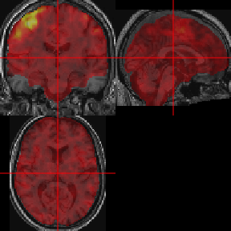

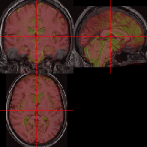

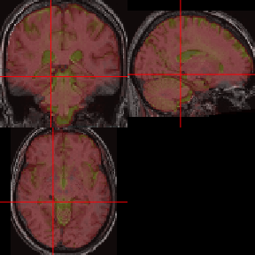

```r
contrast_query_list = list(
  list(name = "LeftHand",
       weights = 1,
       threshold_type = "FWE",
       number_extent_voxels = 0,
       mask_type = "None"),
  list(name = "RightHand",
       weights = 2,
       threshold_type = "FWE",
       number_extent_voxels = 0,
       mask_type = "None")
)

contrast_query_list =
  list(
    list(
    name = "All Contrasts",
    weights = Inf,
    threshold_type = "FWE",
    number_extent_voxels = 0,
    mask_type = "None")
  )
if (have_matlab()) {
  display = all(Sys.getenv("DISPLAY") != "")
  desktop = display
  result_format = "csv"
  results = spm12_results(
    spm = first_model$spmmat,
    units = "Volumetric",
    result_format = result_format,
    contrast_list = contrast_query_list,
    clean = FALSE,
    display = display,
    desktop = FALSE,
    write_images = "binary_clusters",
    image_basename = "thresholded",
    install_dir = install_dir
    )
  out_results = list.files(
    pattern = paste0("spm.*[.]", result_format),
    path = output_directory,
    full.names = TRUE)
  # out_dir = spm_directory(spm = first_model$spmmat)
}
```

```
## # Running matlabbatch job
```

```
## # Creating matlabbatch job
```

```
## # Adding SPMDIR: /var/folders/1s/wrtqcpxn685_zk570bnx9_rr0000gr/T//Rtmpmjc48T/spm12\n
```

```
## Running job: /var/folders/1s/wrtqcpxn685_zk570bnx9_rr0000gr/T//Rtmpmjc48T/filebd71d765567.m, which calls /var/folders/1s/wrtqcpxn685_zk570bnx9_rr0000gr/T//Rtmpmjc48T/filebd717913f5eb.m
```

```
## Command run is:
```

```
## matlab  -nodesktop -nosplash    -r  "try, run('/var/folders/1s/wrtqcpxn685_zk570bnx9_rr0000gr/T//Rtmpmjc48T/filebd71d765567.m'); catch err, disp(err.message); exit(1); end; exit(0);"
```

```
## # Result is 0
```

## Bibliography

```r
bib = '@article{ashburner2005unified,
  title={Unified segmentation},
  author={Ashburner, John and Friston, Karl J},
  journal={Neuroimage},
  volume={26},
  number={3},
  pages={839--851},
  year={2005},
  publisher={Elsevier}
}'
```